# Project number I : Investigate a Dataset

### Dataset to use : No-show-appointments from kaggle

- Introduction
- Data Wrangling
- Exploratory Data Analysis
- Conclusions

## Introduction

**The dataset**: This dataset collects information from 100k medical appointments in Brazil and is focused on the question of **whether or not patients show up for their appointment**. A number of characteristics about the patient are included in each row :

- ScheduledDay: tells us on what day the patient set up their appointment.
- Neighborhood: indicates the location of the hospital.
- Scholarship: indicates whether or not the patient is enrolled in Brasilian welfare program Bolsa Família.
- The last column: it says ‘No’ if the patient showed up to their appointment, and ‘Yes’ if they did not show up.

### Questions

1. Is scholarship associated with higher show rate?
2. Are the females more committed to attending appointment?
3. Does disease affect appointment show rate ?

```python
# Here I will import statements for all of the packages that I plan to use.
import pandas as pd
import numpy as np
import matplotlib.pyplot as plt
%matplotlib inline
```

## Data Wrangling

> This section is dedicated to load the data, check for cleanliness, and then trim and clean the dataset for analysis.

### General Properties

```python
# Load the dataset using pandas
df=pd.read_csv('noshowappointments-kagglev2-may-2016.csv')
# check the first 5 rows of the dataset
df.head()
```

|  | PatientId | AppointmentID | Gender | ScheduledDay | AppointmentDay | Age | Neighbourhood | Scholarship | Hipertension | Diabetes | Alcoholism | Handcap | SMS_received | No-show |
| --- | --- | --- | --- | --- | --- | --- | --- | --- | --- | --- | --- | --- | --- | --- |
| 0 | 2.987250e+13 | 5642903 | F | 2016-04-29T18:38:08Z | 2016-04-29T00:00:00Z | 62 | JARDIM DA PENHA | 0 | 1 | 0 | 0 | 0 | 0 | No |
| 1 | 5.589978e+14 | 5642503 | M | 2016-04-29T16:08:27Z | 2016-04-29T00:00:00Z | 56 | JARDIM DA PENHA | 0 | 0 | 0 | 0 | 0 | 0 | No |
| 2 | 4.262962e+12 | 5642549 | F | 2016-04-29T16:19:04Z | 2016-04-29T00:00:00Z | 62 | MATA DA PRAIA | 0 | 0 | 0 | 0 | 0 | 0 | No |
| 3 | 8.679512e+11 | 5642828 | F | 2016-04-29T17:29:31Z | 2016-04-29T00:00:00Z | 8 | PONTAL DE CAMBURI | 0 | 0 | 0 | 0 | 0 | 0 | No |
| 4 | 8.841186e+12 | 5642494 | F | 2016-04-29T16:07:23Z | 2016-04-29T00:00:00Z | 56 | JARDIM DA PENHA | 0 | 1 | 1 | 0 | 0 | 0 | No |

```python
# learn more about the dataset
df.info()
```

```
<class 'pandas.core.frame.DataFrame'>
RangeIndex: 110527 entries, 0 to 110526
Data columns (total 14 columns):
 #   Column          Non-Null Count   Dtype
---  ------          --------------   -----
 0   PatientId       110527 non-null  float64
 1   AppointmentID   110527 non-null  int64
 2   Gender          110527 non-null  object
 3   ScheduledDay    110527 non-null  object
 4   AppointmentDay  110527 non-null  object
 5   Age             110527 non-null  int64
 6   Neighbourhood   110527 non-null  object
 7   Scholarship     110527 non-null  int64
 8   Hipertension    110527 non-null  int64
 9   Diabetes        110527 non-null  int64
 10  Alcoholism      110527 non-null  int64
 11  Handcap         110527 non-null  int64
 12  SMS_received    110527 non-null  int64
 13  No-show         110527 non-null  object
dtypes: float64(1), int64(8), object(5)
memory usage: 11.8+ MB
```

> The data set is composed of 14 columns and 110527.

> There is no missing data.

> There is some columns with incorrect data type like the ScheduledDay and AppointmentDay they need to be conveted to date as as type.

```python
df.describe()
```

|  | PatientId | AppointmentID | Age | Scholarship | Hipertension | Diabetes | Alcoholism | Handcap | SMS_received |
| --- | --- | --- | --- | --- | --- | --- | --- | --- | --- |
| count | 1.105270e+05 | 1.105270e+05 | 110527.000000 | 110527.000000 | 110527.000000 | 110527.000000 | 110527.000000 | 110527.000000 | 110527.000000 |
| mean | 1.474963e+14 | 5.675305e+06 | 37.088874 | 0.098266 | 0.197246 | 0.071865 | 0.030400 | 0.022248 | 0.321026 |
| std | 2.560949e+14 | 7.129575e+04 | 23.110205 | 0.297675 | 0.397921 | 0.258265 | 0.171686 | 0.161543 | 0.466873 |
| min | 3.921784e+04 | 5.030230e+06 | -1.000000 | 0.000000 | 0.000000 | 0.000000 | 0.000000 | 0.000000 | 0.000000 |
| 25% | 4.172614e+12 | 5.640286e+06 | 18.000000 | 0.000000 | 0.000000 | 0.000000 | 0.000000 | 0.000000 | 0.000000 |
| 50% | 3.173184e+13 | 5.680573e+06 | 37.000000 | 0.000000 | 0.000000 | 0.000000 | 0.000000 | 0.000000 | 0.000000 |
| 75% | 9.439172e+13 | 5.725524e+06 | 55.000000 | 0.000000 | 0.000000 | 0.000000 | 0.000000 | 0.000000 | 1.000000 |
| max | 9.999816e+14 | 5.790484e+06 | 115.000000 | 1.000000 | 1.000000 | 1.000000 | 1.000000 | 4.000000 | 1.000000 |

```python
# check the if there is duplicated rows
sum(df.duplicated())
```

```
0
```

> No duplicated lines

```python
# check if the dataset is balanced and discover more the diffrent value of each column
df['No-show'].value_counts()
```

```
No     88208
Yes    22319
Name: No-show, dtype: int64
```

```python
df['Hipertension'].value_counts()
```

```
0    88726
1    21801
Name: Hipertension, dtype: int64
```

```python
df['Neighbourhood'].value_counts()
```

```
JARDIM CAMBURI                 7717
MARIA ORTIZ                    5805
RESISTÊNCIA                    4431
JARDIM DA PENHA                3877
ITARARÉ                        3514
                               ...
ILHA DO BOI                      35
ILHA DO FRADE                    10
AEROPORTO                         8
ILHAS OCEÂNICAS DE TRINDADE       2
PARQUE INDUSTRIAL                 1
Name: Neighbourhood, Length: 81, dtype: int64
```

```python
df['SMS_received'].value_counts()
```

```
0    75045
1    35482
Name: SMS_received, dtype: int64
```

```python
df['Handcap'].value_counts()
```

```
0    108286
1      2042
2       183
3        13
4         3
Name: Handcap, dtype: int64
```

### Data Cleaning

```python
# change the type of  ScheduledDay to date
df['ScheduledDay']=pd.to_datetime(df['ScheduledDay'])

# change the type of  AppointmentDay to date
df['AppointmentDay']=pd.to_datetime(df['AppointmentDay'])
```

```python
# check the modifications
df.info()
```

```
<class 'pandas.core.frame.DataFrame'>
RangeIndex: 110527 entries, 0 to 110526
Data columns (total 14 columns):
 #   Column          Non-Null Count   Dtype
---  ------          --------------   -----
 0   PatientId       110527 non-null  float64
 1   AppointmentID   110527 non-null  int64
 2   Gender          110527 non-null  object
 3   ScheduledDay    110527 non-null  datetime64[ns, UTC]
 4   AppointmentDay  110527 non-null  datetime64[ns, UTC]
 5   Age             110527 non-null  int64
 6   Neighbourhood   110527 non-null  object
 7   Scholarship     110527 non-null  int64
 8   Hipertension    110527 non-null  int64
 9   Diabetes        110527 non-null  int64
 10  Alcoholism      110527 non-null  int64
 11  Handcap         110527 non-null  int64
 12  SMS_received    110527 non-null  int64
 13  No-show         110527 non-null  object
dtypes: datetime64[ns, UTC](2), float64(1), int64(8), object(3)
memory usage: 11.8+ MB
```

## Exploratory Data Analysis

> In this section our mission is to compute statistics and create visualizations with the goal of addressing the research questionsn the Introduction.

### Research Question 1 : Is scholarship associated with higher show rate?

> **Be careful** the encoding of the last column: it says ‘No’ if the patient showed up to their appointment, and ‘Yes’ if they did not show up.

```python
df['Scholarship'].value_counts()
```

```
0    99666
1    10861
Name: Scholarship, dtype: int64
```

```python
df.groupby(['Scholarship'])['No-show'].value_counts()
```

```
Scholarship  No-show
0            No         79925
             Yes        19741
1            No          8283
             Yes         2578
Name: No-show, dtype: int64
```

```python
Scholars= df['Scholarship'].value_counts()[0]/len(df)
print(Scholars)
No_Scholars=df['Scholarship'].value_counts()[1]/len(df)
print(No_Scholars)
```

```
0.9017344178345562
0.09826558216544373
```

[figure not shown]

```python
scholars_bar = plt.bar(0, Scholars, width=.3, color ='blue', label='Scholarship' )
no_scholars_bar = plt.bar(1, No_Scholars, width=.3, color ='orange', label='No_Scholarship' )
plt.xticks([0, 1], ['No', 'Yes'])
plt.xlabel('Scholarship')
plt.ylabel('percentage of patients')

plt.title('Proportions Scholarship');
plt.legend();
```

> only 9,82% have scholarship

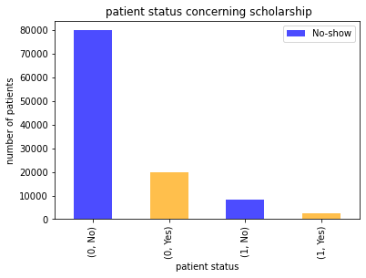

```python
#Here, we'll use a plot bar to show how many scholars and no scholars actually show up for their appointment as opposed to those who don't.

df.groupby(['Scholarship'])['No-show'].value_counts().plot(kind='bar', alpha=.7, color=['blue', 'orange'] );

plt.xlabel('patient status')
plt.ylabel('number of patients')

plt.title(' patient status concerning scholarship');
plt.legend();

# (0,No) no schlars and show up their appointment
# (0,Yes) no schlars and don't show up their appointmen
# (1,No) schlars and show up their appointmen
# (1,Yes) schlars and don't show up their appointmen
```

### Research Question 2 : Are the females more committed to attending appointment?

```python
df['Gender'].value_counts()
```

```
F    71840
M    38687
Name: Gender, dtype: int64
```

```python
# we will use only the row of patients who showed up to their appointment
showed = df[df['No-show'] == 'No']
showed.shape
```

```
(88208, 14)
```

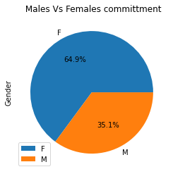

```python
# we will use a pie chart to show the percentage females and male who are committed to their appointment
showed['Gender'].value_counts().plot(kind='pie',autopct='%1.1f%%');
plt.title(' Males Vs Females committment');
plt.legend();
```

```python
df.head()
```

|  | PatientId | AppointmentID | Gender | ScheduledDay | AppointmentDay | Age | Neighbourhood | Scholarship | Hipertension | Diabetes | Alcoholism | Handcap | SMS_received | No-show |
| --- | --- | --- | --- | --- | --- | --- | --- | --- | --- | --- | --- | --- | --- | --- |
| 0 | 2.987250e+13 | 5642903 | F | 2016-04-29 18:38:08+00:00 | 2016-04-29 00:00:00+00:00 | 62 | JARDIM DA PENHA | 0 | 1 | 0 | 0 | 0 | 0 | No |
| 1 | 5.589978e+14 | 5642503 | M | 2016-04-29 16:08:27+00:00 | 2016-04-29 00:00:00+00:00 | 56 | JARDIM DA PENHA | 0 | 0 | 0 | 0 | 0 | 0 | No |
| 2 | 4.262962e+12 | 5642549 | F | 2016-04-29 16:19:04+00:00 | 2016-04-29 00:00:00+00:00 | 62 | MATA DA PRAIA | 0 | 0 | 0 | 0 | 0 | 0 | No |
| 3 | 8.679512e+11 | 5642828 | F | 2016-04-29 17:29:31+00:00 | 2016-04-29 00:00:00+00:00 | 8 | PONTAL DE CAMBURI | 0 | 0 | 0 | 0 | 0 | 0 | No |
| 4 | 8.841186e+12 | 5642494 | F | 2016-04-29 16:07:23+00:00 | 2016-04-29 00:00:00+00:00 | 56 | JARDIM DA PENHA | 0 | 1 | 1 | 0 | 0 | 0 | No |

### Research Question 3 : Does disease affect appointment show rate?

```python
# in this questions we will try to undrestand how the Hipertension, Diabetes and Alcoholism affect appointment show rate
```

```python
df.groupby(['Diabetes'])['No-show'].value_counts()
```

```
Diabetes  No-show
0         No         81695
          Yes        20889
1         No          6513
          Yes         1430
Name: No-show, dtype: int64
```

```python
df.groupby(['Hipertension'])['No-show'].value_counts()
```

```
Hipertension  No-show
0             No         70179
              Yes        18547
1             No         18029
              Yes         3772
Name: No-show, dtype: int64
```

```python
df.groupby(['Alcoholism'])['No-show'].value_counts()
```

```
Alcoholism  No-show
0           No         85525
            Yes        21642
1           No          2683
            Yes          677
Name: No-show, dtype: int64
```

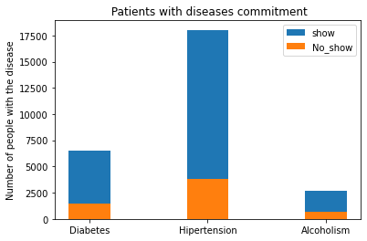

```python
# we will define a function that return the number of patinets with X disease who show up their appointment and those who don't
def value(x):
    patinent_show = (df.groupby([x])['No-show'].value_counts())[1][1]
    patinent_no_show = (df.groupby([x])['No-show'].value_counts())[1][0]
    return patinent_show,patinent_no_show


labels = ['Diabetes', 'Hipertension','Alcoholism']
show_values = [value('Diabetes')[1], value('Hipertension')[1], value('Alcoholism')[1]]
No_show_values = [value('Diabetes')[0], value('Hipertension')[0],value('Alcoholism')[0] ]
width = 0.35

fig, ax = plt.subplots()
ax.bar(labels, show_values, width,  label='show')
ax.bar(labels, No_show_values, width , label='No_show')
plt.title(' Patients with diseases commitment');
ax.set_ylabel('Number of people with the disease')

ax.legend()
plt.show()
```

> the majority of patients who have diseases show up their appointment

## Conclusions and limitations

The dataset used was relatively undrestadblbe and clean, in fact no large challenges were faced, and some little issues like anproprite data type were quickly fixed

We were able to answer several questions regarding our dataset and draw some conclusions thanks to the data exploration phase.

##### Limitations :

Some of the project's constraints stemmed from the dataset itself, as we were comparing an unbalanced sample, with a disproportionately large number of females, which made drawing conclusions quite difficult.

Another drawback is the small number of features in the dataset; however, if we had more precise information on the patients themselves, such as their employment status, the number of children they had, and their family composition, our analysis may be more accurate and precise.